# Reproducible Research Assignment 1

Daniel R.

## Loading and preprocessing the data

I used the below packages for my code in this report

```r
library(plyr)
library(dplyr)
library(ggplot2)
library(lubridate)
library(reshape2)
```

I used the below code to load the data and remove any NA values

```r
#Load the data, remove NAs
data_1 <- read.csv("C:\\Users\\Daniel\\Documents\\R\\data\\activity.csv")
data_NA <- is.na(data_1$step)
data_2 <- data_1[!data_NA,]
```

## What is the mean total number of steps taken per day?

First, I consolidated the data using tapply, (I had to remove the NA’s once again):

```r
tsum <- tapply(data_2[,1],data_2$date,FUN = sum)
tsum_NA <- is.na(tsum)
tsum <- tsum[!tsum_NA]
tsum
```

```
## 2012-10-02 2012-10-03 2012-10-04 2012-10-05 2012-10-06 2012-10-07 2012-10-09
##        126      11352      12116      13294      15420      11015      12811
## 2012-10-10 2012-10-11 2012-10-12 2012-10-13 2012-10-14 2012-10-15 2012-10-16
##       9900      10304      17382      12426      15098      10139      15084
## 2012-10-17 2012-10-18 2012-10-19 2012-10-20 2012-10-21 2012-10-22 2012-10-23
##      13452      10056      11829      10395       8821      13460       8918
## 2012-10-24 2012-10-25 2012-10-26 2012-10-27 2012-10-28 2012-10-29 2012-10-30
##       8355       2492       6778      10119      11458       5018       9819
## 2012-10-31 2012-11-02 2012-11-03 2012-11-05 2012-11-06 2012-11-07 2012-11-08
##      15414      10600      10571      10439       8334      12883       3219
## 2012-11-11 2012-11-12 2012-11-13 2012-11-15 2012-11-16 2012-11-17 2012-11-18
##      12608      10765       7336         41       5441      14339      15110
## 2012-11-19 2012-11-20 2012-11-21 2012-11-22 2012-11-23 2012-11-24 2012-11-25
##       8841       4472      12787      20427      21194      14478      11834
## 2012-11-26 2012-11-27 2012-11-28 2012-11-29
##      11162      13646      10183       7047
```

```r
mean_steps <- round(mean(tsum),2)
median_steps <- round(median(tsum),2)
```

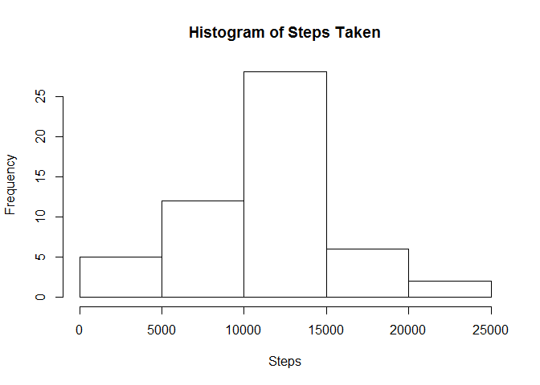

```r
hist(tsum,breaks = 6, xlab = "Steps",
     main = "Histogram of Steps Taken")
```

## What is the average daily activity pattern?

To calculate I used tapply to consolidate the data into average steps taken for each interval.

```r
#create new data frame
data_3 <- data_2

#find average of each interval across all days
taverage <- tapply(data_3[,1],data_3$interval,
                   FUN = mean)
```

Using the above data, I used ggplot to make a time series plot for each interval averaged across all days.

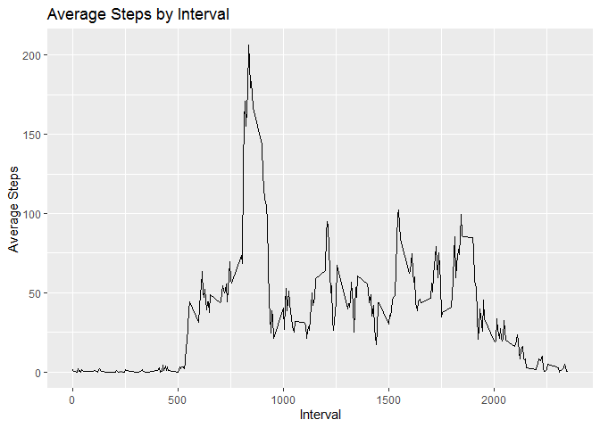

```r
#create the data frame for ggplot
x <- as.numeric(as.character(names(taverage)))
y <- taverage
ggdata_1 <- data.frame(x,y)
#Plot the data
g <- ggplot(data = ggdata_1, aes(x = ggdata_1$x,
                                 y = ggdata_1$y,
                                 group =1))
g + geom_line()+ggtitle("Average Steps by Interval")+
        labs(y = "Average Steps", x ="Interval")
```

Lastly, I found the interval at which the max average steps occurred:

```r
max_interval = names(which.max(taverage))
```

The interval with the highest average was 835.

## Imputing missing values

Below is the code to calculate the number of missing values:

```r
#Calculate number of missing values and create new data frame
NAcount <- sum(is.na(data_1[,1]))
data_4 <- data_1
```

There are 2304 missing values

My strategy for imputing missing values was to use the average steps for each interval. So, created a data frame that mapped each interval to its average steps:

```r
#Create data frame matching intervals to their averages
avgDF <- data.frame(names(taverage),taverage)
names(avgDF) <- c("interval","Interval Average")
```

Then I merged the above data frame with the original data and replaced the missing values with the interval averages

```r
#merge original data with interval averages
mergetest <- merge(data_4,avgDF, by.x = "interval",by.y = "interval")
#Map interval averages to steps with NA values
mergetest[is.na(mergetest$steps),"steps"] <- mergetest[is.na(mergetest$steps),"Interval Average"]
```

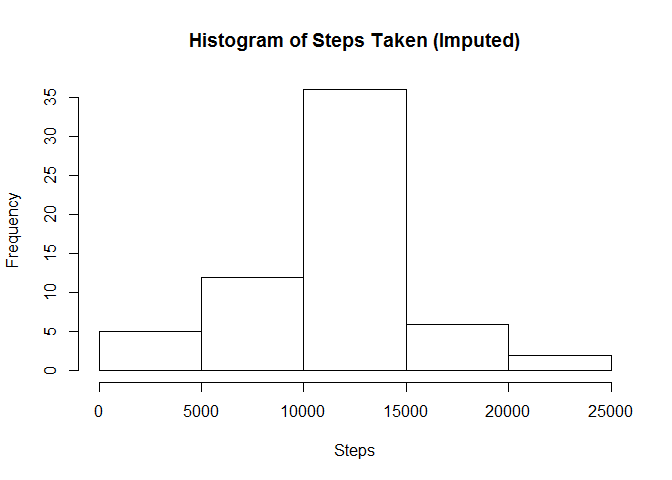

```r
#sum the total steps (with imputed values) for each day
Impsum <- tapply(mergetest[,2],mergetest$date, FUN = sum)
#plot histogram of Impsum
hist(Impsum,breaks = 6, xlab = "Steps",
     main = "Histogram of Steps Taken (Imputed)")
```

```r
#calculate mean and median of imputed data
median_steps_imp <- round(median(Impsum),2)
mean_steps_imp <- round(mean(Impsum),2)
```

## Are there differences in activity between weekdays and weekends?

I used the weekdays function to add a column to the dataframe denoting dates that were weekends or weekdays

```r
#change the date from factor to date
mergetest$date <- as.Date(mergetest$date,format = "%Y-%m-%d")
#Add a weekday column
mergetest$weekday <- weekdays(mergetest$date)
#Find indexes of Saturday and Sunday and replace them with "Weekend"
wIndex <- mergetest$weekday == "Sunday" |
        mergetest$weekday == "Saturday"
mergetest$weekday[wIndex] <- "Weekend"
#Find indexes of non Weekends and replace with "Weekday"
wIndex2 <- mergetest$weekday != "Weekend"
mergetest$weekday[wIndex2] <- "Weekday"
```

Then I extracted the relevant columns, aggregated by interval and weekday, and finally plotted the results using ggplot

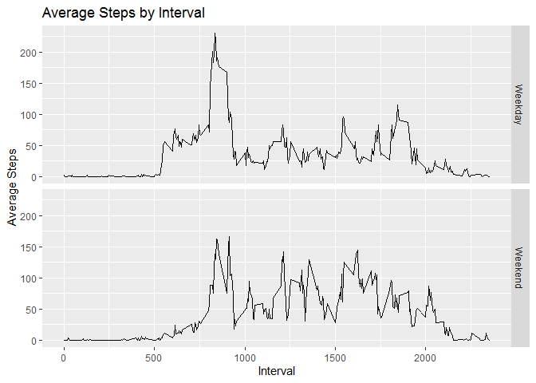

```r
#Select relevant columns
weekData <- mergetest[,c(1,2,5)]
#Aggregate by interval and weekday
weekData2 <- aggregate(.~interval+weekday,weekData, mean)
#Plot using ggplot, and separate by weekday factor
g2 <- ggplot(data = weekData2, aes(x = weekData2$interval,
                                   y = weekData2$steps,
                                   group =1))
g2 + geom_line()+facet_grid(rows=vars(weekday))+
        ggtitle("Average Steps by Interval")+
        labs(y = "Average Steps", x ="Interval")
```